# Module 2: Measuring Value & Quality

MHIA 6160 | Value & Quality in Healthcare | 1.50 | W27

Dr. Cameron B. Chiarot

## Module 2.1

### Access vs. Realized Access (Utilization)

## The Concept of Access

**Theoretical Frameworks**

- Behavioural
- Technological
- Health Systems
- Unified

## Behavioural Framework (Andersen & Aday)

**Framework:**

- A population-centric approach examining why individuals access health services.

**Focus:**

- Individual and household decision-making regarding accessing healthcare services.

**Paradigm:**

- Shift from *Static* resource availability to a *Dynamic* behaviour (e.g., socioeconomics)

## Behavioural: Distinct Operational Stages

**Potential Access:**

- Structural capacity and enabling resources available to an individual or community.

**Realized Access:**

- Actual utilization of health services (e.g., undergoing treatment).

**Equitable vs. Inequitable Access:**

- Determining whether service utilization is driven fairly by health needs (equitable) vs. socioeconomic, demographic, or social biases (inequitable).

## Behavioural: Value and Quality

**Need as the Core Driver of Value:**

- Differentiates between *Perceived Need* and *Evaluated Need*.
- Value is realized when these align.

**Value and Quality are mediated through:**

- *Predisposing Characteristics*: Demographics, beliefs, and culture.
- *Enabling Resources*: Family income, out-of-pocket costs, and social networks.

**Client Satisfaction as an Outcome:**

- Patient satisfaction and perceived quality of care not just endpoints.
- Critical feedback loops that dictate whether individuals will return for future care.

## Behavioural: Public vs. Private

**Public Sector Lens:**

- Mitigate socioeconomic disparities.
- Enabling resources for vulnerable populations (public insurance).

**Private Sector Lens:**

- Market-driven enabling resources (out-of-pocket payments, private insurance).
- Can improve availability for those with high purchasing power.

**System-Level Integration:**

- Highlights the tension between private health seeking behaviour and public policy goals.
- Demonstrates that sustainable access requires aligning public with private delivery.

## Technological Approach (Frost & Reich)

**Framework:**

- Translating innovations into widespread impact in low-resource settings.

**Focus:**

- Inventing and evaluating new technologies (e.g., vaccines, drugs, equipment).

**Paradigm:**

- An *access gap* exists between the health technology and its utilization.

**Question**

- What are potential access gaps?

## Technological Approach: The Four A’s Framework

**Architecture:**

- Institutional arrangements, governance, policies, and stakeholders.

**Availability:**

- Products are reliably procured, shipped, stocked, and distributed.

**Affordability:**

- Remove financial barriers.

**Adoption:**

- Driving behavioural, cultural, and operational acceptance.

## Technological Approach: Navigating Value and Quality

**The Efficacy-Effectiveness Gap:**

- Technologies proven to work under controlled clinical trial frequently fail in real-world settings due to insufficient infrastructure, trained personnel, and operational environments.

**Perceived vs.. Intrinsic Quality:**

- Low-income populations frequently encounter sub-standard, degraded, or counterfeit medical goods, which severely damages trust in public health interventions and formal healthcare systems.

**Redefining Value:**

- True product value must account for operational feasibility (e.g., specialized equipment).

## Technological Approach: Public vs. Private

**Public Sector:**

- Driven primarily by equity goals, and population health mandates, yet hindered by policy bottlenecks, rigid procurement systems, and budget constraints.

**Private Sector:**

- Operates efficiently with distribution and retail channels, but typically concentrates products in urban markets where consumers possess higher purchasing power.

**Hybrid Approach:**

- Requires public-private partnerships that leverage efficiency while safeguarding public interest, equity, and affordability.

## Health Systems Approach (Penchansky & Thomas)

**Framework:**

- Access as the structural *goodness of fit* between health systems and patients.

**Focus:**

- Multi-dimensional, moving beyond static resources or purely individual behaviours and describes the functional relationship between a health delivery system and its target population.

**Paradigm:**

- Access is achieved when health service design, delivery structures, and operations align seamlessly with the economic, geographic, and cultural realities of the population.

## Health Systems Approach: The Five A’s Framework

Operationalized into **five** distinct and interdependent dimensions:

| **Dimension** | **Definition** | **Strategic Implication** |
| --- | --- | --- |
| Availability | Adequacy of supply | Matches resources to population need |
| Accessibility | Relationship between supply and patient | Infrastructure & Geography |
| Accommodation | Organization of supply to accept patients | Operational efficiency |
| Affordability | Cost relative to patient financial capacity | Public insurance vs. Out-Of-Pocket |
| Acceptability | Alignment between provider attributes and patient attitudes | Equitable access |

## Health Systems Approach: Navigating Value and Quality

**Structural Quality vs. Client Experience:**

- Technical or clinical quality is meaningless if the operational delivery is unacceptable or unaccommodating to the patient.

**Value as Operational Efficiency:**

- Value is evaluated by how efficiently the five dimensions are managed (e.g., A clinic that has high availability of drugs but terrible accessibility offers limited value).

**Consumer Satisfaction as the Ultimate Metric:**

- Satisfaction is not as a secondary outcome, rather it is a diagnostic indicator of where the system’s goodness of fit is failing.

## Health Systems Approach: Public vs. Private

**The Public Sector Lens:**

- Optimized for accessibility, affordability, and availability for entire populations, but frequently struggles with accommodation and acceptability due to bureaucratic rigidness, long wait times, and funding constraints.

**The Private Sector Lens:**

- Excels in accommodation (e.g., shorter wait times) and acceptability (e.g., customer service), but systematically fails on affordability.

**Systemic Integration Challenge:**

- Highlights why populations often bypass public infrastructure (e.g. fails on accommodation, patients will seek out private alternatives, trading off affordability).

## Unified Approach (Chiarot et al., 2025)

**Theoretical Availability:**

- The mere presence of healthcare resources does not guarantee they translate into population health improvements.

**Potential Access:**

- The structural and geographic potential for a population to consume healthcare services (e.g., hospital beds, proximity to clinics, workforce).

**Realized Access (Utilization):**

- Actual **consumption** of healthcare services and the degree to which individuals successfully navigate the system to receive care (i.e., *transaction*).

## Unified Framework for the Concept of Access

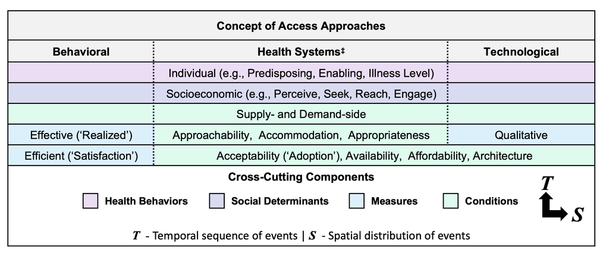

## Module 2.2

### Economic Drivers of Utilization: Macro- and Micro-Conditions

## Macroeconomic Conditions (**Shocks**)

**Climate Change**

- Flooding
- Severe Drought
- Extreme Heatwaves

**Infectious Disease**

- Endemics (e.g., Malaria)
- Pandemics (e.g., SARS_CoV_2)
- Epidemics (e.g., Influenza)

**Economic Crisis**

- Inflation or Hyperinflation
- Banking Collapse
- Sovereign Default

**Geopolitics**

- Conflict
- Trade Sanctions
- Supply Chain Protectionism

## Microeconomic Conditions (**Stressors**)

**Demand-Side Conditions**

- Health-seeking behaviour
- Socioeconomics
- Demographics
- Geography (e.g., travel)

**Supply-Side Conditions**

- Workforce
- Quantity of Health Facilities
- Type of Health Facilities
- Funding and Funding Models

## Demand-Side Conditions: Geography (Urban vs. Rural Contexts)

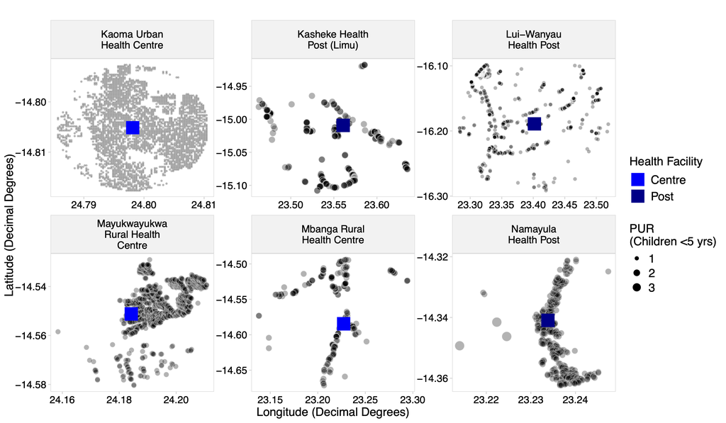

## Demand-Side Conditions: Geography (Travel)

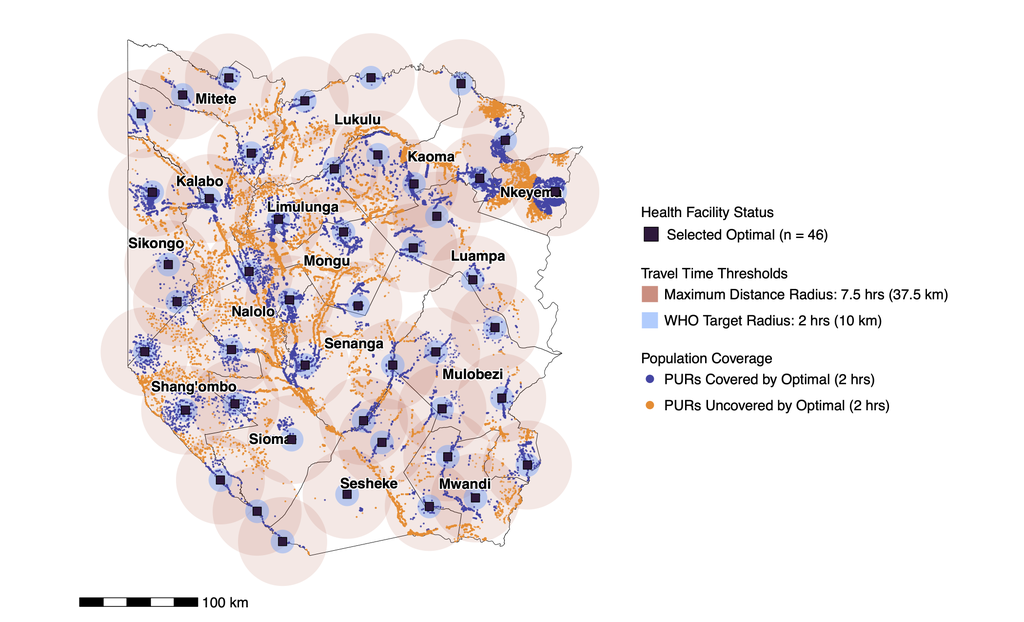

## Demand-Side Conditions: Population

[figure not shown]

[figure not shown]

## Demand-Side Conditions: Geography (Urban vs. Rural Contexts)

**System Lens:**

- Public mandates must ensure spatial equity so that geographic isolation does not dictate health outcomes.

**Industry Lens:**

- Private digital health and mobile platforms can bridge accessibility gaps, though affordability remains a hurdle.

**Source:** Chiarot et al., 2025

## Supply-Side Conditions: Health Facilities

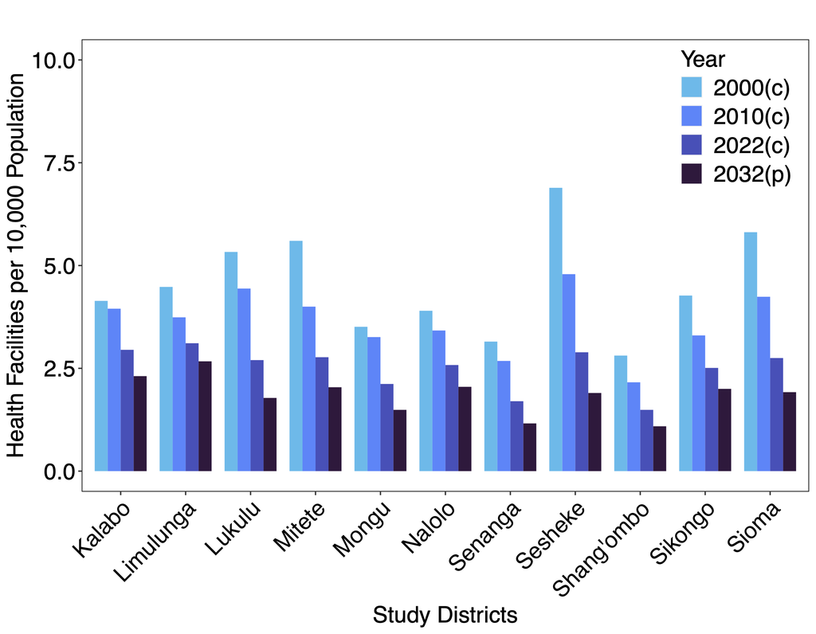

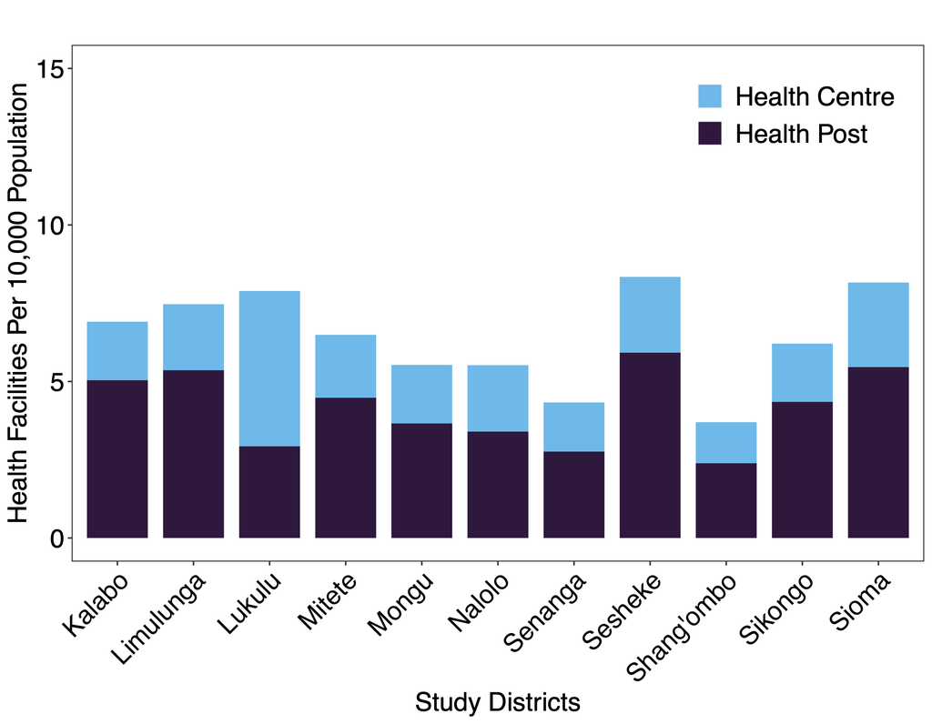

## Supply-Side Conditions: Workforce

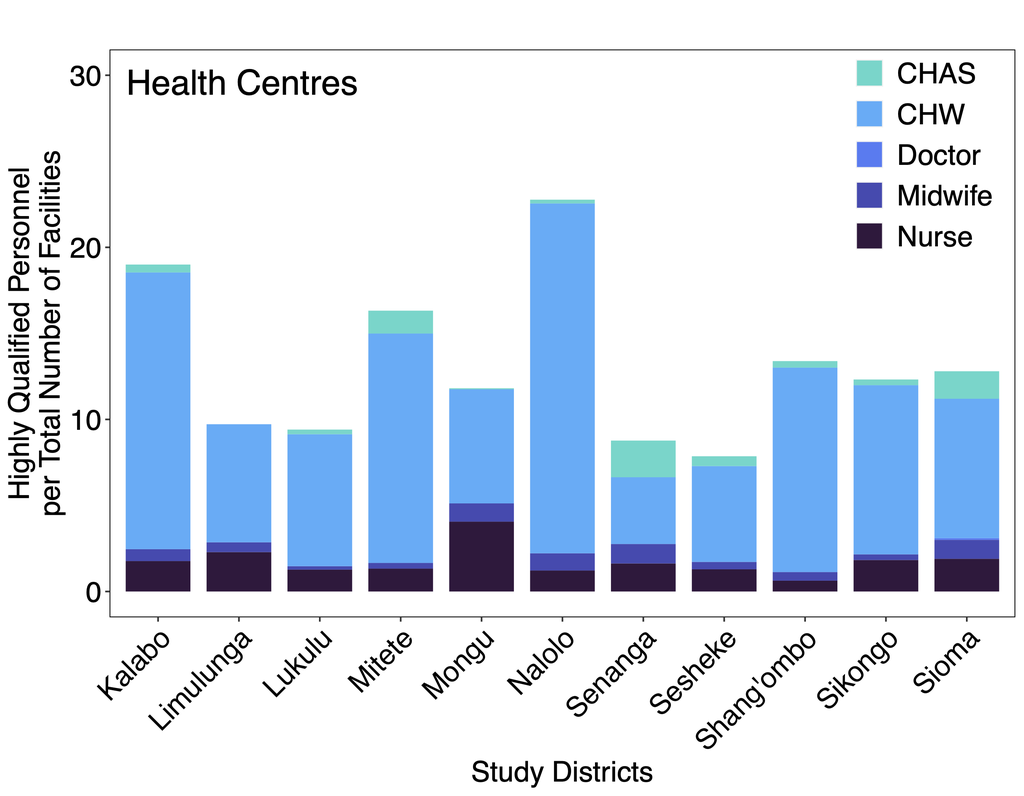

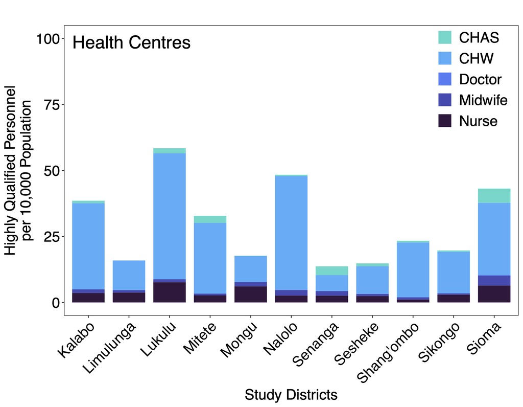

## Adverse Interactions (Econosyndemic)

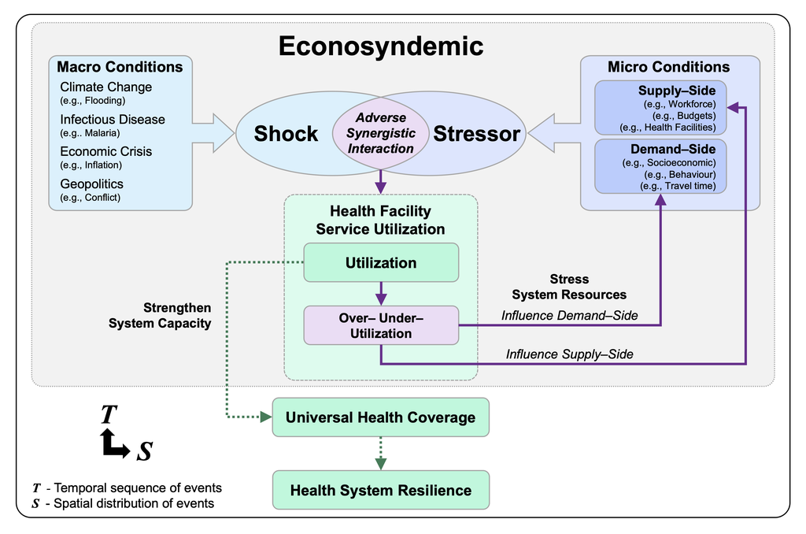

## Health Outcomes: General Utilization (Out Patient)

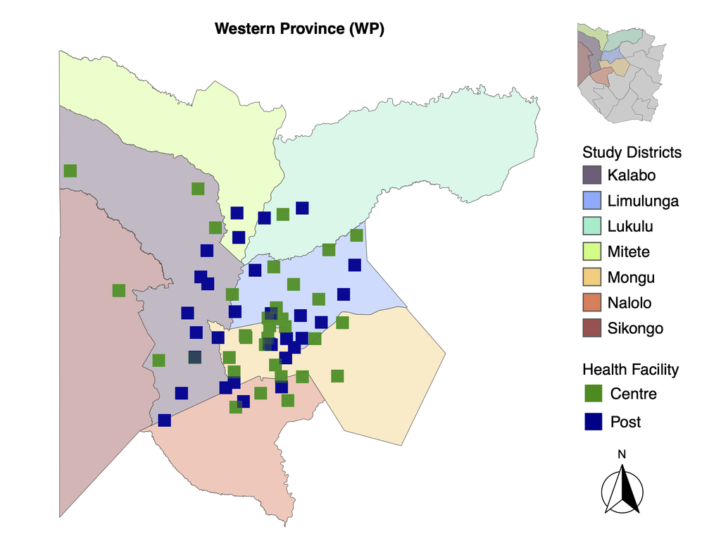

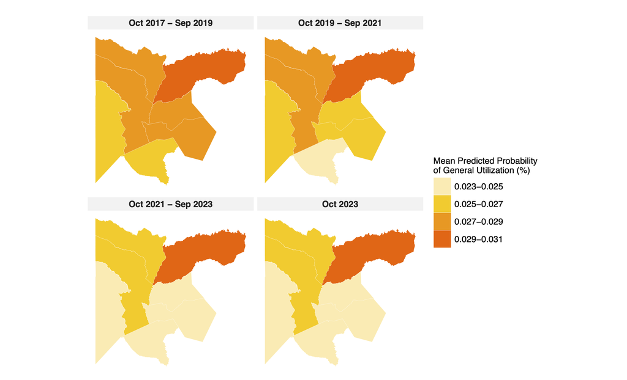

## Health Outcomes: Antenatal Care (ANC)

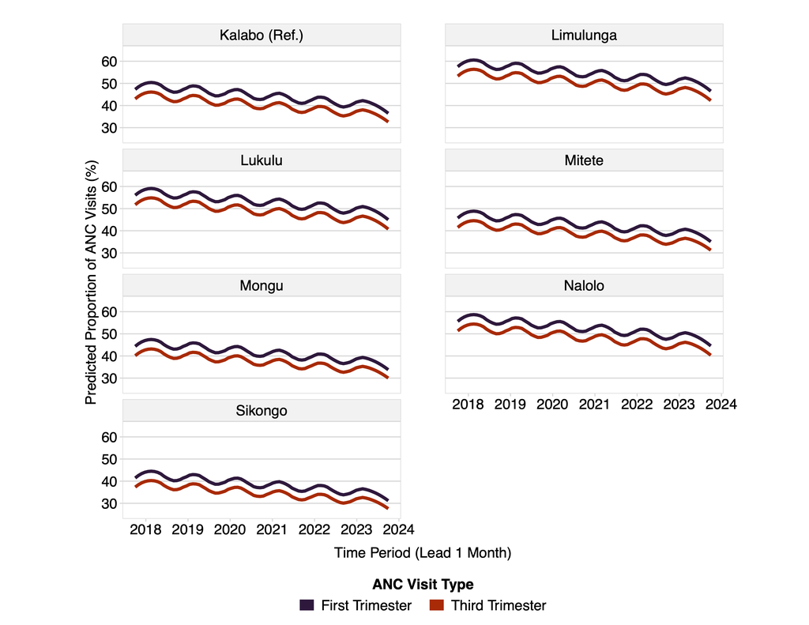

## Health Outcomes: Antenatal Care (ANC)

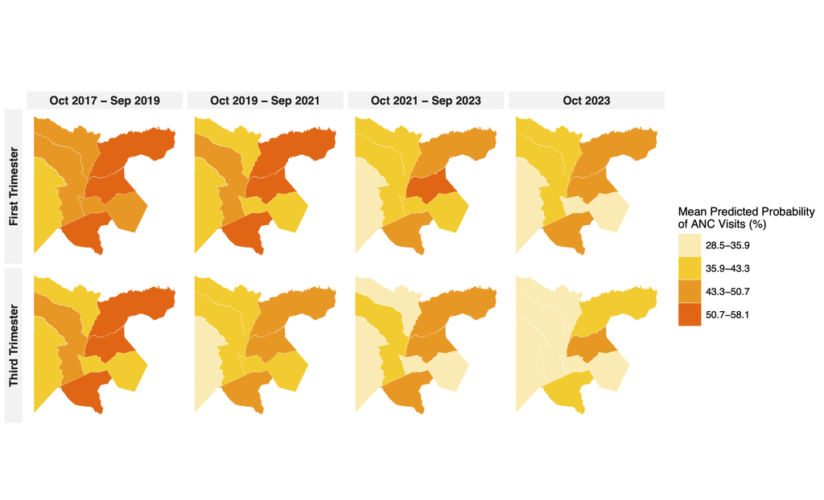

## Module 2.3

### Evaluating & Measuring Utilization

## Framework (Donabedian, 1988)

**Focus & Objective:**

- A framework to evaluate the quality and performance of medical care.

**Core Components:**

- **Structure:** The settings, instruments, and human/financial resources available.
- **Process:** The actual delivery, implementation, and utilization of care
- **Outcomes:** The resulting recovery, restoration of health, survival, and patient satisfaction.

**Key Linkages:**

- A linear causal chain: **Structure $\rightarrow$ Process $\rightarrow$ Outcome**

## Key Performance Indicators (KPIs)

**Translating Volume into Evidence**

- Use standardized metrics that quantify operational and clinical performance.

**Core Utilization Indicators**

- **Crude vs. Standardized Rates:** Adjust for age, sex, and risk (fair comparisons).
- **Admission & Readmission Rates:** Tracking inpatient flows to identify bottlenecks.
- **Length of Stay (LOS):** Measuring resource consumption efficiency per inpatient episode.

**Strategic Utility for Leaders**

- Transforming data into actionable dashboards to monitor capacity, equity, and value.

## The Mathematics of Crude & Standardization

- **Crude Utilization Rate:**

$$\text{Crude Rate} = \left(\frac{\text{Total Events}}{\text{Total Population}}\right) \times \text{Multiplier}$$

- **Direct Standardized Rate:**

$$\text{Direct Standardized Rate} = \frac{\sum \left( \text{Stratum Rate} \times \text{Standard Population in Stratum} \right)}{\text{Total Standard Population}} \times \text{Multiplier}$$

- **Why it matters:** Direct standardization removes the confounding effect of different population age or risk structures, making cross-regional comparisons valid.

## The Canadian Context

**The Donabedian Lens in Action:**

- Acts as a powerful lens for organizing Canadian utilization themes.
- Separates what we **have** (capacity/resources) from what we **do** (access/flow) and what we **get** (health results).

**Operationalizing Canadian Health Data:**

- Mapping national priorities to these categories, leadership can diagnose systemic friction.
- We utilize standardized metrics from the **Canadian Institute for Health Information**.

## The Canadian Utilization Matrix

| **Canadian Theme** | **Structure (Capacity & Resources)** | **Process (Access & Flow)** | **Outcome (Result & Impact)** |
| --- | --- | --- | --- |
| Primary Care Barriers | Family Physicians per 100,000 population | Canadians with a Regular Health Provider | Ambulatory Care Sensitive Conditions (ACSC) |
| Wait Times | Operating Room Hours / MRI Machine Density | Wait Times for Priority Procedures | Patient-Reported Outcome Measures (PROMs) |
| Alternate Level of Care (ALC) | Long-Term Care Bed Supply | ALC Days as % of Total Patient Days | Hospital Harm Results / Readmission Rates |
| Workforce Supply | Health Workforce Inflows/Outflows | Overtime Rates & Sick Time | Avoidable Mortality |
| Data & Integration | EMR Adoption Rates in Primary Care | Repeat Hospital Stays for Mental Health | 30-Day All-Cause Readmission Rate |

Source: Adapted from Canadian Institute for Health Information (CIHI).

## Equity & Disaggregation

**The Fallacy of Aggregate Averages:**

- System-level averages conceal systemic inequities.
- True value cannot be achieved if utilization is driven exclusively by high-income.

**Equity-Sensitive Measurement Strategies:**

- **Stratification by Socioeconomic Quintile:** Use household income brackets.
- **Geographic Disaggregation:** Comparing rural vs. urban access barriers.
- **Intersectionality in Care:** Examining how overlapping demographic factors.

**Strategic Implication:**

- Leaders must use disaggregated data to direct resources where the gap is widest.

## Strategic Action

**From Dashboards to Decisions:**

- Utilization data are not merely technical reporting artifacts; they are strategic instruments for high-performance health leadership.

**The Executive Application:**

- **Identifying Bottlenecks:** Pinpoint where capacity restrictions constrain patient flow.
- **Targeted Resource Reallocation:** Direct investments toward unmet need or barriers..
- **Performance Accountability:** Use metrics for accountability.

**Core Leadership Mandate:**

- Translating complex utilization patterns into a single, compelling *bottom line* that aligns public sector equity mandates with operational efficiency.

## Public vs. Private

| **Dimension** | **Public Sector Lens** | **Private Sector Lens** |
| --- | --- | --- |
| Core Objective | Population health mandates, universal access, and equity | Financial viability, market share, and investor return |
| Primary Metrics | Age-standardized rates, uninspected needs, regional coverage | Throughput, bed-turnover, revenue-per-encounter, wait times |
| Equity Focus | High: Tracks disparities across socioeconomic and geographic lines | Low: Focuses primarily on insured or paying customer segments |
| Operational Driver | Allocative efficiency and macro-budgetary constraints | Technical efficiency and profit-maximizing margins |

## Module 2.4

### The Effectiveness-Efficiency Frontier

## Defining the Frontier (Porter’s Value Framework)

**Theoretical Foundation:**

- Grounded in Michael Porter’s value framework ($Value = \frac{Outcomes}{Costs}$)
- True value is measured around outcomes relative to the total costs expended.

**Technical vs. Allocative Efficiency:**

- **Technical Efficiency:** Producing the maximum possible clinical outcome.
- **Allocative Efficiency:** Distributing health resources to maximize societal welfare.

**The Frontier Concept:**

- Maximum possible health outcomes achievable for any given level of expenditure.
- Points inside the frontier signal operational waste or sub-optimal utilization.

## Effectiveness vs. Efficiency Trade-offs

**Bridging Donabedian to the Frontier:**

- **Structure & Process (Efficiency):** Minimize waste and control costs.
- **Outcomes (Effectiveness):** Maximize clinical recovery and patient health gains.

**The Core Trade-off:**

- Pushing toward the frontier requires balancing cost against clinical quality.
- Systems that focus solely on cutting process costs often degrade outcomes.

**Navigating the Tension:**

- Health leadership requires optimizing the trade-off
- Enhanced clinical effectiveness does not lead to fiscal unsustainability.

## The Cost-Quality-Value Nexus

**Synthesizing the Equation:**

- **Effectiveness:** Maximize the numerator.
- **Efficiency:** Optimizing the denominator.

**The Danger of Sub-Optimal Shifts:**

- **Cost-Cutting without Quality:** Lowering expenditures destroys true value.
- **Adding Cost without Outcomes:** Increasing resource inputs results in operational waste.

**Executive Mandate:**

- High-performance leaders do not just cut budgets.
- Restructure delivery models to expand outcomes relative to costs.

## Visualizing the Effectiveness-Efficiency Frontier

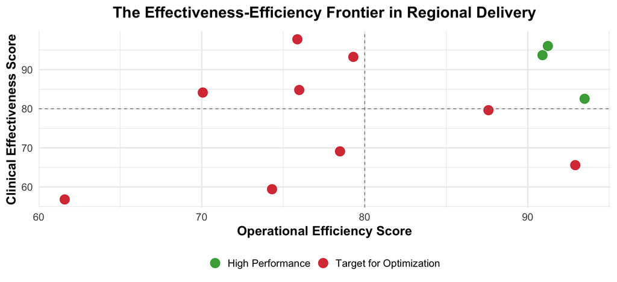

## Public vs. Private Lens on the Frontier

**Public Sector Lens (System Mandate):**

- Objective: Operates under macro-level equity and population-wide coverage goals.
- Focus: Shifting entire regional populations closer to the frontier.
- Challenge: Bureaucratic inertia and rigid structures can push public systems inward.

**Private Sector Lens (Industry Mandate):**

- Objective: Operates on market-clearing efficiencies, innovation, and margin optimization.
- Focus: Technical efficiency, reducing unit costs, and maximizing throughput.
- Challenge: Can restrict access for vulnerable groups, prioritizing return over equity.

## Strategic Leadership on the Frontier

**The Executive Mandate:**

- Cannot manage health systems effectively by looking at cost containment and clinical quality in isolation.

**Key Leadership Actions:**

- **Eliminate Operational Waste:** Identify and correct processes inside the frontier.
- **Redesign Care Pathways:** Shift delivery from high-cost to lower-cost settings.
- **Balance Dual Priorities:** Ensure that efficiency gains do not compromise equity.

**Conclusion:**

- Mastering the effectiveness-efficiency frontier is essential for modern healthcare.

## Week 3 Deliverable: Case Analysis (**Weight: 30%**)

**Assignment Overview:**

- **Core Task:** Comparative critique of two organizations through the lens of Value & Quality.

**Strategic Pillars (Choose One):**

1. **Effectiveness vs. Efficiency:** How do the entities balance clinical outcomes with resource optimization?
2. **Centralized vs. Decentralized Governance:** How does organizational structure impact high-quality care?
3. **Public vs. Private Sector Interface:** How do different funding or delivery mandates influence value for the end-user?

**Full requirements:** Refer to the course outline.